# Loan Completion Analysis

## by Jeff Mitchell

## Investigation Overview

The purpose of this analysis is to see what factors impact on the likelihood of a loan being completed. The main focus was on Loan completion and specific factors of the member and the loan that influenced loan completion.

## Dataset Overview

The dataset contains information on nearly 114,000 loans from Prosper. Only loans that had been concluded (paid off succesfully or failed to be paid off) were used for the analysis, which reduced the sample number to 55076. There were loans that were missing values that could not be corrected which resulted in a further 591 loans being removed.

Attributes of interest included Loan completion status, Borrower APR, Debt-to-income ratio, Term, Loan Origination Quarter, Monthly Loan Payments and Employment status. There were 81 data points per loan, many of which were not relevant for this analysis. This number was reduced to 16 for the initial analysis. The features that proved to be of the most interest were Debt-to-income ratio, Monthly Loan Payments and Borrower APR.

## Overall Completion Rate

For this analysis, loans that were no longer current were included in the analysis subset. This included loans that had been paid off ('Completed') and those that were not paid off ('Not completed'). Overall the completion rate was 69%.

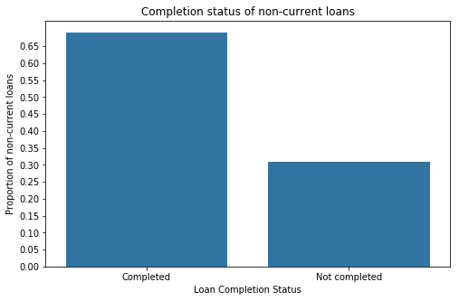

```python
# Plot LoanCompleted column as %
base_color = sb.color_palette()[0]
n_points = loans.shape[0]
max_count = loans['LoanCompleted'].value_counts().max()
max_prop = max_count / n_points
tick_props = np.arange(0, max_prop, 0.05)
tick_names = ['{:0.2f}'.format(v) for v in tick_props]

plt.figure(figsize=[8, 5])
sb.countplot(data = loans, x = 'LoanCompleted', color = base_color)
plt.yticks(tick_props * n_points, tick_names)
plt.ylabel('Proportion of non-current loans')
plt.xlabel('Loan Completion Status')
plt.title('Completion status of non-current loans')
plt.show();
```

## Number of Loans by Term

Most of the loans were for a 36-month term (90% of loans). A much smaller amount were for a 60-month term (7%) and the smallest category was the 12-month term loans (3%).

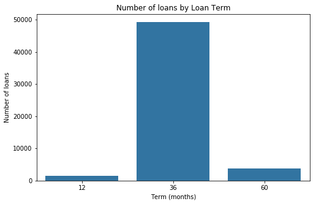

```python
plt.figure(figsize=[8, 5])
sb.countplot(data = loans, x = 'Term', color = base_color)
plt.xlabel('Term (months)')
plt.ylabel('Number of loans')
plt.title('Number of loans by Loan Term')
plt.show();
```

## Monthly Loan Payments

After a log transformation the Monthly Loan Payments showed a normal distribution. The mean was \$224 and 75% were below \$301.

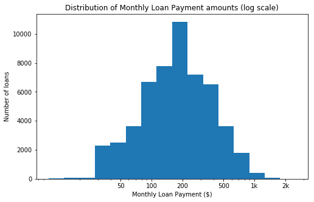

```python
log_binsize = 0.15
bins = 10 ** np.arange(1, np.log10(loans['MonthlyLoanPayment'].max())+log_binsize, log_binsize)

plt.figure(figsize=[8, 5])
plt.hist(data = loans, x = 'MonthlyLoanPayment', bins = bins)
plt.xscale('log')
plt.xticks([50, 100, 200, 500, 1000, 2000], [50, 100, 200, 500, '1k', '2k'])
plt.xlabel('Monthly Loan Payment ($)')
plt.ylabel('Number of loans')
plt.title('Distribution of Monthly Loan Payment amounts (log scale)')

plt.show()
```

## Debt-to-income Ratios

The mean Debt-to-income ratio was 0.29 and 75% were below 0.3. There was a right skew to the data due to some outliers at a ratio of 10.

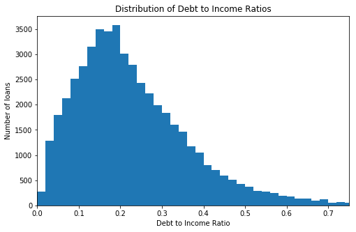

```python
binsize = 0.02
bins = np.arange(0, without_outliers['DebtToIncomeRatio'].max()+binsize, binsize)

plt.figure(figsize=[8, 5])
plt.hist(data = without_outliers, x = 'DebtToIncomeRatio', bins = bins)
plt.xlabel('Debt to Income Ratio')
plt.ylabel('Number of loans')
plt.title('Distribution of Debt to Income Ratios')
plt.xlim(0,0.75)
plt.show();
```

The dominant level in a feature generally has a loan completion rate close to the mean. For instance, most loans are of a 36-month term and the loan completion rate for these loans is the same as the 69% sample average. Where we see some interesting results are with the outliers and levels of features above and below those that are the highest represented. Here we can see where each of these features can have a positive or negative impact on the completion of a loan.

## Loan Completion by Term

The vast majority of loans were for a term of 36-months and the proportion of these loans that were successfully completed was the same as the sample mean of 69%. The 60-month loans were slightly worse with a 66% completion rate. 12-month loans were the stand out with a completion rate of 95%. While the number of 12-month loans in the data was small, these results suggest that a shorter loan term increases the chance of a loan being paid off.

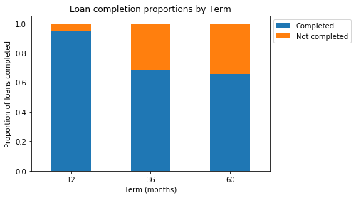

```python
term_props = loans.groupby('Term')['LoanCompleted'].value_counts(normalize=True).unstack()

term_props.plot(kind='bar', stacked='True', title='Loan completion proportions by Term', rot=0).legend(
    bbox_to_anchor=(1, 1))
plt.xlabel('Term (months)')
plt.ylabel('Proportion of loans completed')
plt.show();
```

## Loan Completion by Debt-to-income Ratio

Higher debt-to-income ratios appear to lower the chance of completing a loan. Loan completion rates were fairly steady up to a debt-to-income ratio of 0.3, which was around 75% of the loans. Above this ratio the loan completion rate began to fall. It bottomed out at 0.7 but after that it never reaches the same level of loan completion as seen at a ratio of 0.3.

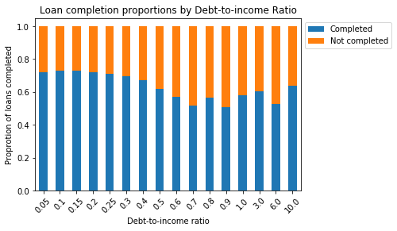

```python
debt_props = loans.groupby('DebtRatioBin')['LoanCompleted'].value_counts(normalize=True).unstack()
debt_props.plot(kind='bar', stacked='True', title='Loan completion proportions by Debt-to-income Ratio',
                rot=45).legend(bbox_to_anchor=(1, 1))
plt.xlabel('Debt-to-income ratio')
plt.ylabel('Proprotion of loans completed');
```

## Loan Completion by Monthly Loan Payment

The variation in loan completion rate across Monthly Loan Payment amounts was less pronounced. The highest completion rate was at the highest level of monthly payments, however, there were not many loans in these bins. Monthly payments between \$750 and \$1000 showed the lowest completion rates. Between \$50 and \$750 there was not a lot of fluctuation either side of the overall mean of 69% and so Monthly Loan Payment value appears to have a smaller impact on loan completion than either loan term or debt-to-income ratio.

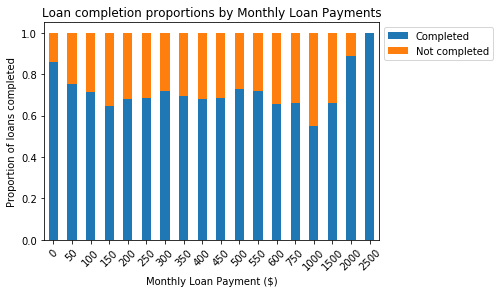

```python
# Compare Loan Outcome Status and Debt Consolidation
monthly_props = loans.groupby('MonthlyPaymentBin')['LoanCompleted'].value_counts(normalize=True).unstack()
monthly_props.plot(kind='bar', stacked='True', title='Loan completion proportions by Monthly Loan Payments', rot=45).legend(
    bbox_to_anchor=(1, 1))
plt.ylabel('Proportion of loans completed')
plt.xlabel('Monthly Loan Payment ($)');
```

## Loan Completion by Borrower APR and Debt-to-income ratio

Loans with low Borrower APR scores and low Debt-to-income ratios tend to be paid off. Increasing one of these features tends to increase the risk of the loan not being paid off - a high Borrower APR or a high Debt-to-income ratio made it much more likely a loan would not be completed. The chances of a loan not being paid off were much higher when both features had high values.

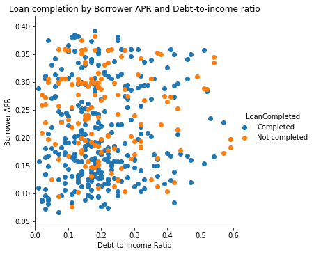

```python
# Plot a sample of the data to make the plot easier to read
samples = np.random.choice(loans.shape[0], 1000, replace = False)
loans_samp = loans.loc[samples,:]

g = sb.FacetGrid(data = loans_samp, hue = 'LoanCompleted', size = 5)
g.map(plt.scatter, 'DebtToIncomeRatio', 'BorrowerAPR')
g.set(xlim = (0,0.6), title='Loan completion by Borrower APR and Debt-to-income ratio', xlabel='Debt-to-income Ratio',
     ylabel='Borrower APR')
g.add_legend();
```